# BIMM 145 Project 2

### Scientific Question:

**Does dextromethorphan, a common over-the-counter cough syrup, target the same biological pathways in the brain to the known pathways ketamine in its use as an antidepressant?**

Ketamine, a well-known psychedelic pharmaceutical drug, functions as an NMDA Receptor antagonist. This blockage of the NMDA receptor is thought to be responsible for ketamine's antidepressant effects in patients sufferring from major depressive disorder (Hashimoto et al 2016).

The over-the-counter cough syrup known as dextromethorphan is also known to be an NMDA receptor antagonist (Cole et al 1989). This suggests that the dextromethorphan may also be effective in the treatment of depression through similar biological pathways involving the NMDA receptor. The structures of ketamine and dextromethorphan can be found using PubChem (https://pubchem.ncbi.nlm.nih.gov/). According to the database website:

"PubChem is the world's largest collection of freely accessible chemical information. Search chemicals by name, molecular formula, structure, and other identifiers. Find chemical and physical properties, biological activities, safety and toxicity information, patents, literature citations and more."

### Scientific Hypothesis:

**If dextromethorphan is known to behave similarly to ketamine in its activity as an NMDA receptor antagonist, then ketamine and dextromethorphan will have similar chemical structures and consequently the pharmaceuticals will equally dock with the NMDA receptor in a similar location when being used as an antidepressant.**

The two compound structures of ketamine and dextromethorphan were downloaded from PubChem and saved as a SDF file, which was used in both the fingerprinting as well as the table displaying the structures and data from PubChem of both compounds.

The first cheminformatics method used in answering the scientific question and testing the hypothesis was Fingerprinting and Similarity Mapping. Fingerprinting is a cheminformatics tool that allows 2D and 3D molecular structures to be converted into a comparable numerical code. By comparing the codes between different chemicals, in this case dextromethorphan and ketamine, we are able to determine the level of similarity between them which is important in testing the scientific hypothesis proposed above.

The fingerprints were also presented in a similarity map. By displaying the fingerprints in a similarity map, we are able to visualize the similarity in structure between the two drugs. Using color, the map is able to highlight struvtural areas of similarity and differences between the two chemicals (Riniker et al 2013).

The second anaysis performed was the bioinformatics tool of displaying the structures of both dextromethorphan and ketamine in a table, along with the other PubMed data on the two pharmaceuticals. This provides a stronger understanding of the compounds and their chemical structures, which is part of my scientific hypothesis.

To answer the second part of my question, I used pymol to display a 3D image of the NMDA receptor proteins. The protein structures were downloaded from the RCSB Protein Data Bank (PDB). According to the website of RCSB PDB, this database contains "information about the 3D shapes of proteins, nucleic acids, and complex assemblies". From this database, I was able to obtain the necessary PDB-formatted files and import these files into my notebook for use in pymol.

## Part 1: Installing Packages

Some of the packages used in my notebook include:

- PubChemPy: PubChemPy is a package that works with the PubChem Database as well as their chemical toolkits. This program allows the user to search information found on PubChem through Biopython. The tools provided in this package allow for searching for chemicals via their name, substructure, and chemical properties. The package also contains tools that allow for creating PNG images of the structures, unique fingerprints for similarity analysis, and property tables for multiple chemicals in a given file. Additional information about PubChemPy can be found here: (https://pubchempy.readthedocs.io/en/latest/)
- RDKit: RDKit is a cheminformatics, open source package that contains multiple tools for use in python. This toolkit can be used for both 2D and 3D compounds. The package provides tools that can be used to search for compounds and their molecular structures. It also provides tools for loading molecules into the notebook, as well as reading, writing, and drawing molecular structures. The package can also work to align molecules and perform structural analysis to determine similarities between molecules, print maps, and more. Additional information about RDKit package can be found here: (https://www.rdkit.org/docs/Overview.html)
- NGLView: The NGLView is a Python Widget that allows for printing interactive molecular structures and their trajectories. This package is essential for displaying the protein structures. The package contains access to the Protein Data Bank (PDB) to allow for proteins to be searched via their PDB ID, or read proteins via a PDB file. This information is able to be viewed in an interactive image of the molecular structure of the protein. The NGLView package uses the NGL Viewer tool to be able to interact with data from PDB, RCSB, and other analysis libraries. Additional information about the NGLView package can be found here: (http://nglviewer.org/nglview/release/v0.5.1/)
- mols2grid: Mols2Grid is a tool based on the RDKit that allows for creating interactive chemical displays in python. This tool interacts with SDF files, pandas dataframes, and lists of RDKit molecules. The visual contains the 2D structures of small molecules. This display can be customized using parameters to set bond lengths, rename compounds, show specific information from the SDF file, and more. The grid can also be customized to specify the number of molecules displayed per page, the number of columns and rows used, the font and color of the words, and other edits. Additional information about the mols2grid tool can be found here: (https://pypi.org/project/mols2grid/)
- numpy: Numpy is a python library that can be installed using either conda, pip, or packages from online sources. This package allows for use of arrays and metrics in jupyter notebooks. It also allows for the use of mathematical functions in the manipulation and operation of arrays. In the case of this experiment, it is useful in printing and running a fingerprint matrix in fingerprint analysis. The library is most commonly used on matrices and arrays for performing algebraic functions. Additional information about numpy can be found here: (https://docs.dea.ga.gov.au/notebooks/Beginners_guide/07_Intro_to_numpy.html)
- itertools: Itertools is a module in Python that works with iterators, or data types that are used in a "for" loop, in performing iterator-algebraic functions. The tools presented by itertools are used to create more complex iterators from more simple iterators. The package is able to " iterate over data structures that can be stepped over using a for-loop" (https://www.geeksforgeeks.org/itertools-in-python3/). This module contains many functions that can be used to accumulate results, combine iterables and integers, create loops, and more. Additional information about itertools can be found here: (https://docs.python.org/3/library/itertools.html).

```python
pip install pubchempy
```

```python
conda install -c rdkit rdkit
```

[output not shown]

```python
conda install -c conda-forge nglview
```

[output not shown]

```python
conda install -c conda-forge mols2grid
```

```
Solving environment: done

# All requested packages already installed.
```

```python
# import packages and tools from packages
import matplotlib.pyplot as plt
from IPython.display import Image
import pubchempy as pcp
import os
import scipy as scip
import pandas as pd
from rdkit import Chem
from rdkit import DataStructs
from rdkit.Chem import Draw
from rdkit.Chem import rdMolAlign
from rdkit.Chem import AllChem
from rdkit.Chem import rdmolfiles
from rdkit.Chem import PandasTools
from rdkit.Chem import Descriptors
from rdkit.Chem.Draw import IPythonConsole
from rdkit.Chem.rdMolAlign import AlignMol
from rdkit.Chem.Fingerprints import FingerprintMols
from rdkit.Chem.rdmolfiles import ForwardSDMolSupplier
import mols2grid
import numpy as np
import itertools
import nglview as ngl
```

```
RDKit WARNING: [11:00:12] Enabling RDKit 2019.09.3 jupyter extensions
```

## Part 2A: Reading in the Data Files and Performing a Cheminformatics Analysis

### (Fingerprinting, Similarity Analysis, and Similarity Mapping)

**SDF Files**: The files containing the 3D structures of dextromethorphan and ketamine were downloaded from PubMed in the form of a SDF File. SDF files contain the complete description about the structural and molecular organization of molecules, and this information is stored in a structured format. The file describes each atom's location in relation to another, using x, y, and z coordinates to outline the locations of each molecule and thus store essential information about the molecular structure. The SDF file can then be used by Jupyter Notebook to read the structure of a molecule.

**Molecular Fingerprints**: Molecular fingerprints encode the 3D structure of a compound or molecule into a binary digits, known as bits. This code is able to be used in analysis of the similarity between two molecules. More information on fingerprints can be found here: (https://openbabel.org/docs/dev/Fingerprints/intro.html)

The first step in the code below was to upload and read in the molecules from an SDF File (ketamine and dextromethorphan). These molecules were then turned into molecular fingerprints. Using the fingerprints and the itertools package, we then found the fingerprint analysis between the two molecules and stored this in a matrix, as seen below.

```python
# Here, we load in the SDF file made prior, 'drugs_SDF'.
# 'drugs_SDF' contains SDF format files for ketamine and dextromethorphan
m = Chem.SDMolSupplier('drugs_SDF')
SDFFile= 'drugs_SDF'

# Using the RDKit tool "PandasTools" to read in the SDF file and
# return the data as a pandas dataframe.
drugs=PandasTools.LoadSDF(SDFFile)

# defining the length of the SDF file,
# or the number of compounds being ran in the file.
# in this case, we have two compounds- dextromethorphan and ketamine.
chemical_len = len(drugs)
# print SDF file to check that the file was imported properly into the notebook
print(drugs)
```

```
  PUBCHEM_COMPOUND_CID PUBCHEM_CONFORMER_RMSD  \
0                 3821                    0.6
1              5360696                    0.6

              PUBCHEM_CONFORMER_DIVERSEORDER  \
0  2\n3\n11\n12\n9\n8\n5\n10\n4\n1\n6\n13\n7
1                                       1\n2

                      PUBCHEM_MMFF94_PARTIAL_CHARGES  \
0  18\n1 -0.18\n10 -0.14\n11 0.18\n12 -0.15\n13 0...
1  17\n1 -0.36\n10 0.14\n11 0.27\n14 -0.14\n15 -0...

  PUBCHEM_EFFECTIVE_ROTOR_COUNT  \
0                             3
1                           2.6

                      PUBCHEM_PHARMACOPHORE_FEATURES PUBCHEM_HEAVY_ATOM_COUNT  \
0  5\n1 2 acceptor\n1 3 cation\n1 3 donor\n6 10 1...                       16
1  6\n1 1 acceptor\n1 2 cation\n6 2 3 4 5 6 11 ri...                       20

  PUBCHEM_ATOM_DEF_STEREO_COUNT PUBCHEM_ATOM_UDEF_STEREO_COUNT  \
0                             0                              1
1                             3                              0

  PUBCHEM_BOND_DEF_STEREO_COUNT  ... PUBCHEM_CONFORMER_ID  \
0                             0  ...     00000EED00000002
1                             0  ...     0051CC3800000001

  PUBCHEM_MMFF94_ENERGY PUBCHEM_FEATURE_SELFOVERLAP  \
0               48.0121                      25.371
1               65.3106                      32.062

                           PUBCHEM_SHAPE_FINGERPRINT  \
0  12251169 10 18114454643283242456\n12326174 3 1...
1  10382601 240 18339076102741212184\n10863032 1 ...

                            PUBCHEM_SHAPE_MULTIPOLES  \
0  320.29\n4.06\n2.27\n1.72\n1.26\n0.36\n-0.98\n-...
1  400.74\n5.6\n3.06\n1.56\n9.27\n1.48\n-0.17\n-2...

  PUBCHEM_SHAPE_SELFOVERLAP PUBCHEM_SHAPE_VOLUME PUBCHEM_COORDINATE_TYPE  \
0                   668.351                181.2                2\n5\n10
1                   868.303                216.6                2\n5\n10

        ID                                              ROMol
0     3821  <img data-content="rdkit/molecule" src="data:i...
1  5360696  <img data-content="rdkit/molecule" src="data:i...

[2 rows x 24 columns]
```

We then run a fingerprint similarity analysis to show the similarity scores between dexromethorphan and ketamine. We are using a topological fingerprint analysis because we are only comparing two structures.

```python
# Creating a Fingerprint for Dextromethorphan using SMILE format
mol= Chem.MolFromSmiles('COc1ccc2c(c1)C13CCCCC1C(C2)N(C)CC3')
# importing necessary tool from RDKit
from rdkit.Chem import rdmolops
# Creating the fingerprint in a bit string format
fp = rdmolops.RDKFingerprint(mol, fpSize=2048, minPath=1, maxPath=7).ToBitString()
print(fp)
```

```
000000011010001010011001100101110111101001001101101010010010…
```

```python
# Creating the fingerprint for Ketamine
refmol= Chem.MolFromSmiles('CNC1(c2ccccc2Cl)CCCCC1=O')
# importing necessary tools from RDKit
from rdkit.Chem import rdmolops
# creating the fingerprint for the compound in a bit string
fp = rdmolops.RDKFingerprint(refmol, fpSize=2048, minPath=1, maxPath=7).ToBitString()
print(fp)
```

```
000000101010001010001000100101010010010000010100000100010100…
```

```python
# Uses bit averages to calculate the simililarity between structures

# upload smile format of the two compounds
ms = [Chem.MolFromSmiles('CNC1(c2ccccc2Cl)CCCCC1=O'), Chem.MolFromSmiles('COc1ccc2c(c1)C13CCCCC1C(C2)N(C)CC3')]

# call for the fingerprinting of each molecule from the smiles input above
fps = [Chem.RDKFingerprint(x) for x in ms]
print(fps)

# call for the similarity between each fingerprint
DataStructs.FingerprintSimilarity(fps[0],fps[1])
```

```
[<rdkit.DataStructs.cDataStructs.ExplicitBitVect object at 0x7fdec80523a0>, <rdkit.DataStructs.cDataStructs.ExplicitBitVect object at 0x7fdf18527940>]
```

```
0.3148614609571788
```

```python
suppl= Chem.SDMolSupplier('drugs_SDF')
for mol in suppl:
    print (mol.GetNumAtoms())
```

```
16
20
```

In the code below, we first constructed a smiles format of the compounds from the sdf file for both ketamine and dextromethorphan. These formulas were then used in constructing a similarities map of the two compounds.

**Similarity Map Using Fingerprinting**: A similarity map for fingerprinting is used to visualize the atom similarity between molecules. This map uses the "weight" of each atom in a molecule to determine the color used in the map. A "weight" is calculated by creating a fingerprint of both molecules and removing the bits. If there is a decrease in structural similarity when the bits are removed, the structure is outlined in green. If there is an increase in the structural similarity when bits are removed, then the structure gets highlighted in pink. When there is no change in structural similarity during the removal of the bits in that region, the structure is highlighted in grey. We can use this to visualize the structural similiarities and differences between the two compounds.

```python
# read the molecular formula (Smiles format) of the compounds
m=Chem.MolFromMolFile('3D-ketamine.sdf')
Chem.MolToSmiles(m)
```

```
'CNC1(c2ccccc2Cl)CCCCC1=O'
```

```python
n=Chem.MolFromMolFile('3D-dextro.sdf')
Chem.MolToSmiles(n)
```

```
'COc1ccc2c(c1)C13CCCCC1C(C2)N(C)CC3'
```

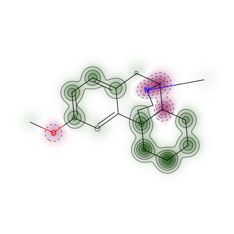

```python
## Similarity Map using fingerprinting

# import the smiles format of ketamine and dextromethorphan
# using ketamine as the reference molecule under the variable refmol
# and dextromethorphan for comparison as the variable mol
mol= Chem.MolFromSmiles('COc1ccc2c(c1)C13CCCCC1C(C2)N(C)CC3')
refmol= Chem.MolFromSmiles('CNC1(c2ccccc2Cl)CCCCC1=O')

# import the tools necessary to draw a similarities map from rdkit
from rdkit.Chem.Draw import SimilarityMaps

# set parameters for map within the similarity map tool
# fpType- the parameter to call the desired types of atom pairs and torsions
# fpType set to normal is calling the default
# fpType set to bv is referencing the bit vectors in the fingerprint
# which will be used in determining the similarity shown in the highlighted colors
# pink (more similar), green (less similar), or grey (no change)
fp = SimilarityMaps.GetAPFingerprint(mol, fpType='normal')
fp = SimilarityMaps.GetTTFingerprint(mol, fpType='normal')
fp = SimilarityMaps.GetMorganFingerprint(mol, fpType='bv')
fig, maxweight = SimilarityMaps.GetSimilarityMapForFingerprint(refmol, mol, SimilarityMaps.GetMorganFingerprint)
```

## Part 2B: Cheminformatics Method 2: Chemical Structure Table Display

Below, we are calling on the mols2grid package tools to display the structures listed in our SDF file collected from PubChem in a table. We are able to visualize the compounds, which is helpful in seeing the two individual structures to compare to the similarity map created and the fingerprinting analysis score calculated above. We can see that the mols2grid was able to convert the SDF file into a Pandas dataframe. The information collected from PubChem is shown below the chemical structure, with the SMILES string used to label each compound.

```python
# using mols2grid tool to create a table of the data from the SDF files
mols2grid.display("drugs_SDF",
                  # setting mols2grid parameters
                  fixedBondLength=25)
```

[interactive chart not shown]

## Part 3: Cheminformatics Plot showing NMDA Receptor Proteins Collected from the Protein Data Bank (PDB)

We are using the tools in nglview to create an interactive 3D image of the proteins involved in the NMDA receptor. The protein IDs for the NMDA Receptor membrane and transport proteins were obtained from RCSB Protein Data Bank (PDB: https://www.rcsb.org/). Using the tools in nglview, we are able to use the protein ID to read the protein structures directly from PDB into our Jupyter Notebook. The shape of the NMDA receptor is important for addressing the scientific question proposed earlier because the shape of the NMDA Receptor is crucial for the docking of dextromethorphan and ketamine onto the receptor. This plot can be used to plot proteins, DNA, and RNA that have an assigned PDB ID in the Protein Data Bank. In this example, it is being used to plot the protein structures of the NMDA Receptor from PDB.

```python
pip install nglview
```

```python
# importing the nglview package as nv
import nglview as nv
```

```python
# we first created a demo protein to make sure that
# the nv package was successfully imported for use in displaying proteins

V = nv.demo()
V
```

```python
# using nglview package to show the protein data bank protein
# by using the protein PDB ID for the NMDA Receptor membrane protein
view = nv.show_pdbid("7EOR")
view
```

[output not shown]

```python
# using nglview package to show the protein data bank protein
# using the protein PDB ID for the NMDA Receptor transport protein
view= nv.show_pdbid("5H8S")
view
```

[output not shown]

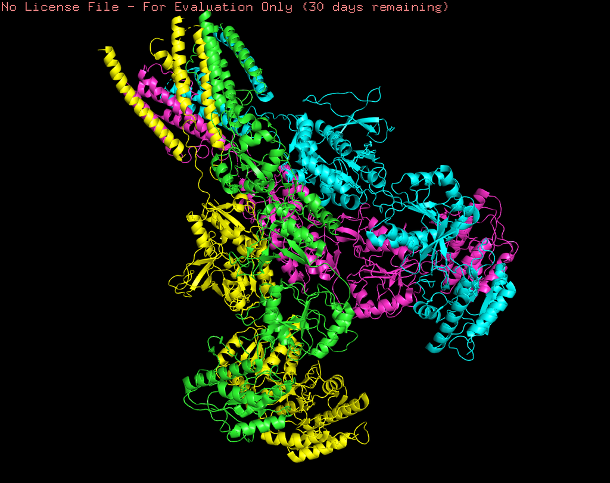

```python
# Using the pymol application, we created an image of the NMDA Receptor
# This image is presented below:
from IPython.display import Image
Image('NMDA_Receptor.png', width=600)
```